# Reproducibility Report for ‘Early Cerebral Constraints on Reading Skills in School-Age Children: An MRI Study’ by Borst et al. (2016, Mind, Brain, & Education)

Jewelia Yao (jkyao@stanford.edu)

November 20, 2022

## Introduction

Borst et al. (2016) examines the relationship between individual morphological differences in the occipital temporal temporal sulcus (OTS), a sulcus in ventral temporal cortex of the brain, and reading skills in school-aged children. Using anatomical magnetic resonance imaging scans from 16 children, this study classified the OTS in both the right and left hemispheres as either interrupted or continuous based on microgyral breaks in the sulcus. Using multiple linear regressions, they related this binary categorization to oral reading scores on the Alouette-R test and found that children whose left OTS had an interruption performed better than children whose left OTS were continuous. This finding suggests that reading skills can be constrained anatomical features of cerebral cortex.

This reproducibility project aimed to reproduce the anatomical labeling anad analysis methods of Borst et al. (2016) so as to generalize the relationship between individual anatomical variability and behavioral measures. The project sought to find a relationship between neuroanatomy and behavior whereby variations in OTS fragmentation predicts reading abilities. In particular, this study aimed to reproduce the specific findings of Borst et al. (2016) and find that an interrupted left OTS, in comparison to a continuous left OTS, predicts reading in another group of participants.

### Justification for choice of study

Understanding the neuroanatomical underpinnings of the development of brain function and behavior has been a major interest of developmental neuroscience. Sulci are features that a) have been shown to act as landmarks or boundaries for functional regions in the brain and b) have individual variabilities that are related to aspects of cognition. As characterizing sulci on an individual level is manual and laborious work, previous studies has often analyzed brain structure using group averages, which wash out individual variability in sulcal patterns. Borst et al. (2016) examines sulci on the individual level and relates it to behavior. This result has been of particular interest to me because I am generally interested in the coupling of brain structure, function, and behaviors related to educational development, and specifically, my upcoming work will examine reading development in kids with/without dyslexia and how it relates to aspects of visual cortex (such as sulcal morphology). My previous work has mostly been in prefrontal cortex, so this would be a great opportunity to explore visual cortex anatomy and its relationship to reading.

### Anticipated challenges

Manually labeling and characterizing sulcal anatomy is time intensive and detailed work requiring an understanding of the neighboring sulcal anatomy and precise judgement given cases of extreme variability in sulcal patterning. This will be challenging as I have never worked in this brain region before and because there will likely be cases in which the OTS is harder to idenfity or determine cutoffs. Additionally, navigating brain data also requires manually checking scans for artifacts and preprocessing the raw data which will add time. However, I have both collected and preprocessed neural data before and do not expect this to be a huge setback.

### Links

Project repository: https://github.com/psych251/borst2016.git

Original paper: https://github.com/psych251/borst2016/blob/master/original_paper/Borst_etal_2016_MindBrainEducation.pdf

**Paradigm**

Labeling PowerPoint: https://github.com/psych251/borst2016/blob/master/LMB_OTS_Labels.pptx

TOWRE: https://github.com/psych251/borst2016/blob/master/TOWREScoring.pdf

## Methods

### Power Analysis

Original effect size: d = 1.19 80% Power: N = 13 per group 90% Power: N = 16 per group 95% Power: N = 20 per group

Given that it is impossible to randomly sample people based on neuroanatomy and given the restrictions of the dataset, the sizes of each group will not be equal. In line with the original study, I will also use 16 subjects because a) the dataset I am using only has 18 subjects so far and b) I think it will be useful to make a point about whether this is enough subjects for making claims about neuroanatomical-behavior relationships.

### Participants

Using pre-collected anatomical MRI data from the Lindamood-Bell (LMB) Reading Study conducted by the Brain Development and Education Lab (Yeatman Lab). 16 typically developing, right-handed children (8 females) between the ages of 9 and 11 were analyzed in this study.

### Materials

**Reading Test** Children’s reading proficiency were evaluated with the Test of Word Reading Efficiency(TOWRE) test, which is a standardized test for assessing oral reading in English. Participants are instructed to read off words orally as fast as possible while maintaining correct pronunciation. The test is time-limited (45 seconds). In the present study, we focused on reading accuracy, which was reflected by the number of words that were correctly read in 45sec. Children were tested after completing the MRI.

**MRI Data Preparation and Acquisition** Pre-acquired three-dimensional (3D) T1-weighted spoiled gradient images using a 3T MRI scanner (GE Discovery Scanner, Stanford University). Image analysis was performed with FreeSurfer (https://surfer.nmr.mgh.harvard.edu), version 6.0. An automated pre-processing step was used to skull-strip the T1 MRIs. Volumes were segmented to grey and white matter to produce a reconstruction of the cortical surface as well as a definition of the cortical ribbon. Images at each processing step for each MRI were visually checked and no motion artifacts or segmentation errors were observed. If segmentations could not be fixed, ubjects were excluded on the basis of motion artifacts or general segmentation artifacts.

### Analysis Plan

**Labeling Procedure**  
Using pre-collected anatomical MRI data, data was processed and manually checked for image quality of T1-weighted anatomical scans in FreeSurfer (https://surfer.nmr.mgh.harvard.edu), a brain imaging program. Using an automated montage code, screenshots of right and left inflated and white inferior view surfaces were compiled in a PowerPoint. The author (JKY) manually labeled each subject’s left and right OTS, and these definitions were confirmed by an expert OTS anatomist (JDY). The OTS labels were then inputed into FreeSurfer for analysis.

Each OTS was defined given the following criteria:

1. OTS is delimited posteriorly by a virtual line extending in the direction of ptCoS to the pre-occipital notch
2. Does not include mid-fusiform sulcus (MFS)
3. Does not include anterior transveres collateral sulcus (atCoS)
4. Does not include pre-occipital notch

Defined OTS in each subject’s left and right hemisphere were then characterized as interrupted (having interruptions or gaps larger than 20mm) or continuous. The 20mm distance was used in previous literature to avoid labeling artifacts or segmentation errors that present as interruptions in a sulcus. Sulci were labeled with a dichotomous variable code for presence or absence of an interruption.

#### Statistical Testing - Reading v. OTS Anatomy

**Reading Statistics & Correlations**

**Multiple Linear Regressions**

To determine if there was a relationship between sulcal anatomy and reading abilities, we tested three models.

Model 1: the number of words correctly read as the outcome variable and (a) the sulcal pattern of the lateral OTS in the left hemisphere, (b) the sulcal pattern of the lateral OTS in the right hemisphere, and (c) age in months as predictor variables

Model 1: $NumWords \sim leftOTS + rightOTS + age$

Model 2: the number of words correctly read as the outcome variable and age in months as a predictor variable

Model 2: $NumWords \sim age$

Model 3: the number of words correctly read as the outcome variable and (a) the sulcal pattern of the lateral OTS in the left hemisphere and (b) the sulcal pattern of the lateral OTS in the right hemisphere as predictor variables

Model 3: $NumWords \sim leftOTS + rightOTS$

**T-Test**

To determine if either interrupted or continuous left OTS - which came out as most predictive of reading in the multiple linear regressions - better predicted reading abilities, we conducted an independent samples t-test comparing reading scores of subjects with interrupted left hemisphere OTS and subjects with continuous left hemisphere OTS.

### Differences from Original Study

Data will not be collected from the same 3T scanner or with the exact same parameters. As T1 images/anatomical scans are typically consistent across 3T scanner, there should not be great scan variation between the quality of anatomical scans from the original study and the present replication.

The sample will also be an English-speaking one, rather than French, so the oral reading test will also be an English test (TOWRE) equivalent to the Alouette-R. There should not be great differences, as the tests are administered similarly and test for the same things ;additionally, most reading tests are highly correlated with one another. TOWRE is in English, but the Alouette-R test is in French and not applicable to this sample.

## Project Progress Check 1

### Measure of success

Successful reproduction will include finding that the left OTS is a better predictor of reading abilities than right OTS or age. Additionally, successful reproduction must find that an interrupted left OTS better predicts reading abilities than a continous left OTS.

This will be computed first by conducting multiple linear regression to deduce if left OTS sulcal pattern is the best predictor of reading abilities, among other variables. If this does not hold true, this will not be a successful reproduction. If this does hold true, a follow-up independent t-test directly comparing interrupted versus continuous left OTS to see if there is a significant difference between the two groups. If there is a significant difference and the interrupted OTS group has the higher mean score on the reading test, the current study will have successfully reproduced the results of the original paper in its entirety.

### Pipeline progress

**Data Preprocessing:** Behavioral data for all 16 subjects has been obtained from the LMB study. Anatomical MRI data has also been obtained and has been labeled by JKY in PowerPoint as of 10/25/2022. Monday, 10/31/22, these labels will be verified by Dr. Jason Yeatman. In the following week, these labels will be inputed into Freesurfer and categorized as interrupted or continuous. See labeling PowerPoint for progress. This link (https://docs.google.com/spreadsheets/d/1eUKGWre1dHoy7ZuhP2gx0D3EApDWflwAo26rfU_YYZQ/edit?usp=sharing) is the spreadsheet for tracking labeling progress.

Data wrangling code will also be done this week. Hoping to have the data preparation code block below filled out in the next couple of days.

**Model Fitting:** In terms of statistics, the three multiple linear regressions and the independent samples t-test have been preliminarily coded and added to the methods section. Models have also been added to the methods section. More formal code will be written in the key analysis section below. Given that the data are still being processed, an official testing of the statistical code can be done after about 11/4/2022.

**Model Evaluation:** This will be done next week (hopefully!). See Model Fitting for details.

Currently, I am thinking of additional exploratory analyses that could be conducted. Any thoughts or suggestions would be great! I am thinking about looking at other morphological features (sulcal depth, gyrification index, sulcal length) or other patterns of language related sulci (inferior frontal sulcus) in the frontal lobe if I have time.

## Progress Check 2

**Data Preprocessing:** Dataframe: created and cleaned dataframe, combined behavioral data with preliminary (hasn’t yet gotten verified by 2nd and 3rd raters) anatomical data

Comments: If it’s okay, I might come bug you or Mike about the power analysis and potentially doing some meta-analysis of the papers that came out saying that the study didn’t replicate. The preliminary data is not completely accurate (realized I made a mistake with my original schematic for some of them) so I’ll be going in this week to double check my labels and then get input from my two other raters. I also have to talk with the RAs who ran the study to double check what behavioral data is best to use (there are two columns for scores on the task and I think one might be z-scored?).

**Model Fitting:** Ran models and t-test (confirmatory) analysis on the unconfirmed data.

**Model Evaluation:** Created rough ggplot to match figure 1 of the paper. Uploaded original figure 1 and dataframe to github folder (see ~writeups/data/)

## Progress Check 3

**Data Preprocessing:** Data (I rated) has been fixed according to criteria in the methods, but I still need to put it into a new dataframe after the other 2 raters have finished rating. Got confirmation from 2nd and 3rd raters that they would be willing to rate the 16 brains (which will be done by Wednesday next week!). Checked with RAs to figure out which behavioral scores to use.

**Model Fitting:** Models and t-test (confirmatory) analysis ready to be re-run on the fixed data.

**Model Evaluation:** Edited ggplot to be cleaner and more like the original paper. Because 16 subjects is not a lot and likely not enough to get a d of 1.19 (see power analysis section, which has been updated), I am planning on doing a meta-analysis. After break, I’ll meet with Mike to talk about the meta-analysis, so still waiting on that!

## Results

### Data preparation

Anatomical data was processed in FreeSurfer using reconall. Using a montage code (screenshot_montage.sh), screenshots of each inferior surface (inflated/white) of the right and left hemispheres for eachs subject was obtained. Data was manually labeled by the author (JKY) in PowerPoint (see LMB_OTS_Labels.pptx). After being confirmed or edited by an expert anatomist, the labels were inputed into FreeSurfer. Subjects were excluded if their MRI data showed too much motion, artifacts, or did not have behavioral data.

```r
#### Prepare data for analysis - create columns etc.
filtered_d <- d %>%
  select("record_id", "rh_OTS", "lh_OTS", "visit_age_yrs_rounded", "twre_swe_ss")

colnames(filtered_d) <- c('ID','rhOTS','lhOTS', 'age', 'towre_score')
```

### Key analysis

```r
sulcal_pattern <- t.test(towre_score ~ lhOTS, data=filtered_d)
sulcal_pattern
```

```
##
##  Welch Two Sample t-test
##
## data:  towre_score by lhOTS
## t = 0.672, df = 2.0874, p-value = 0.5683
## alternative hypothesis: true difference in means between group continuous and group interrupted is not equal to 0
## 95 percent confidence interval:
##  -55.75307  77.39409
## sample estimates:
##  mean in group continuous mean in group interrupted
##                  88.66667                  77.84615
```

```r
std.err <- function(x) sd(x)/sqrt(length(x))

Fig1 <- filtered_d %>%
  group_by(lhOTS) %>%
  summarize(
    se = std.err(towre_score),
    towre = mean(towre_score, na.rm = TRUE))
```

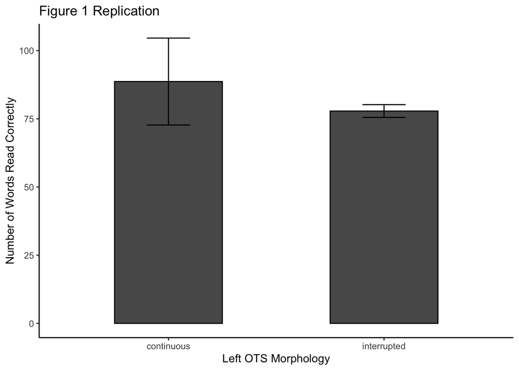

```r
Fig1 %>%
  ggplot(data = ., aes(x = lhOTS, y = towre)) +
    # Aesthetics
    theme_bw() +
    scale_fill_grey() +
    theme(panel.grid.major = element_blank(),
          panel.grid.minor = element_blank(),
          panel.border = element_blank(),
          axis.line = element_line()) +
    # Data
  geom_bar(stat="identity", color="black", position=position_dodge(), width = 0.5) +
  geom_errorbar( aes(ymin = towre-se, ymax = towre+se), width=0.2,position=position_dodge(width = 0.9, preserve = "single")) +
  labs(title="Figure 1 Replication",
        x ="Left OTS Morphology", y = "Number of Words Read Correctly")
```

### Additional analyses

```r
model1 <- lm(towre_score ~ lhOTS + rhOTS + age, data = filtered_d)
summary(model1)
```

```
##
## Call:
## lm(formula = towre_score ~ lhOTS + rhOTS + age, data = filtered_d)
##
## Residuals:
##     Min      1Q  Median      3Q     Max
## -24.369  -7.701  -2.375   6.604  24.369
##
## Coefficients:
##                  Estimate Std. Error t value Pr(>|t|)
## (Intercept)       100.835     43.734   2.306   0.0398 *
## lhOTSinterrupted  -11.210     13.596  -0.825   0.4257
## rhOTSinterrupted   10.237     19.490   0.525   0.6090
## age                -2.175      3.965  -0.549   0.5934
## ---
## Signif. codes:  0 '***' 0.001 '**' 0.01 '*' 0.05 '.' 0.1 ' ' 1
##
## Residual standard error: 13.4 on 12 degrees of freedom
## Multiple R-squared:  0.1914, Adjusted R-squared:  -0.0108
## F-statistic: 0.9466 on 3 and 12 DF,  p-value: 0.4489
```

```r
model2 <- lm(towre_score ~ age, data = filtered_d)
summary(model2)
```

```
##
## Call:
## lm(formula = towre_score ~ age, data = filtered_d)
##
## Residuals:
##     Min      1Q  Median      3Q     Max
## -17.320  -9.502  -3.616   5.713  28.212
##
## Coefficients:
##             Estimate Std. Error t value Pr(>|t|)
## (Intercept)  122.407     27.761   4.409 0.000594 ***
## age           -4.312      2.796  -1.542 0.145295
## ---
## Signif. codes:  0 '***' 0.001 '**' 0.01 '*' 0.05 '.' 0.1 ' ' 1
##
## Residual standard error: 12.76 on 14 degrees of freedom
## Multiple R-squared:  0.1452, Adjusted R-squared:  0.08418
## F-statistic: 2.379 on 1 and 14 DF,  p-value: 0.1453
```

```r
model3 <- lm(towre_score ~ lhOTS + rhOTS, data = filtered_d)
summary(model3)
```

```
##
## Call:
## lm(formula = towre_score ~ lhOTS + rhOTS, data = filtered_d)
##
## Residuals:
##     Min      1Q  Median      3Q     Max
## -26.000  -7.096  -1.346   5.404  26.000
##
## Coefficients:
##                  Estimate Std. Error t value Pr(>|t|)
## (Intercept)        78.000     13.037   5.983 4.57e-05 ***
## lhOTSinterrupted  -16.154      9.903  -1.631    0.127
## rhOTSinterrupted   16.000     15.968   1.002    0.335
## ---
## Signif. codes:  0 '***' 0.001 '**' 0.01 '*' 0.05 '.' 0.1 ' ' 1
##
## Residual standard error: 13.04 on 13 degrees of freedom
## Multiple R-squared:  0.1711, Adjusted R-squared:  0.04355
## F-statistic: 1.342 on 2 and 13 DF,  p-value: 0.2953
```